# Matrix Algebra Homework

Sravani Neelapala

09-20-2023

NOTE: Please do not use any of these functions - stats::prcomp(), FactoMiner::PCA(), ade4::dudi.pca(), ExPosition::epPCA() for completing this homework. You may use these functions to cross check your answers.

## Question 1

Consider the inbuilt dataset `vcd::Baseball`. You can use `help()` function to learn more about the data.

### Task 0: Identify categorical and numeric variables. Keep only the numeric variables in the dataset.

```r
# Include necessary libraries
library(tidyverse)
library(vcd)
# Import data
indata <- vcd::Baseball
head(indata)
```

```
##     name1    name2 atbat86 hits86 homer86 runs86 rbi86 walks86 years atbat hits
## 1      Al   Newman     185     37       1     23     8      21     2   214   42
## 2    Alan    Ashby     315     81       7     24    38      39    14  3449  835
## 3    Alan Trammell     574    159      21    107    75      59    10  4631 1300
## 4    Alan  Wiggins     239     60       0     30    11      22     6  1941  510
## 5    Alex  Trevino     202     53       4     31    26      27     9  1876  467
## 6 Alfredo  Griffin     594    169       4     74    51      35    11  4408 1133
##   homeruns runs rbi walks league86 div86 team86 posit86 outs86 assist86 error86
## 1        1   30   9    24        N     E    Mon      2B     76      127       7
## 2       69  321 414   375        N     W    Hou       C    632       43      10
## 3       90  702 504   488        A     E    Det      SS    238      445      22
## 4        4  309 103   207        A     E    Bal      2B    121      151       6
## 5       15  192 186   161        N     W     LA       C    304       45      11
## 6       19  501 336   194        A     W    Oak      SS    282      421      25
##     sal87 league87 team87
## 1  70.000        A    Min
## 2 475.000        N    Hou
## 3 517.143        A    Det
## 4 700.000        A    Bal
## 5 512.500        N     LA
## 6 750.000        A    Oak
```

```r
# Include only numeric variables. We want to keep the name and make that as row names for the dataset
indata_ <- indata[,-which(sapply(indata, class) == "factor")]
head(indata_)
```

```
##     name1    name2 atbat86 hits86 homer86 runs86 rbi86 walks86 years atbat hits
## 1      Al   Newman     185     37       1     23     8      21     2   214   42
## 2    Alan    Ashby     315     81       7     24    38      39    14  3449  835
## 3    Alan Trammell     574    159      21    107    75      59    10  4631 1300
## 4    Alan  Wiggins     239     60       0     30    11      22     6  1941  510
## 5    Alex  Trevino     202     53       4     31    26      27     9  1876  467
## 6 Alfredo  Griffin     594    169       4     74    51      35    11  4408 1133
##   homeruns runs rbi walks outs86 assist86 error86   sal87
## 1        1   30   9    24     76      127       7  70.000
## 2       69  321 414   375    632       43      10 475.000
## 3       90  702 504   488    238      445      22 517.143
## 4        4  309 103   207    121      151       6 700.000
## 5       15  192 186   161    304       45      11 512.500
## 6       19  501 336   194    282      421      25 750.000
```

```r
# Concatenating first and last name
indata_ <- indata_ %>% unite("fname_lname", c("name1", "name2"))
head(indata_)
```

```
##       fname_lname atbat86 hits86 homer86 runs86 rbi86 walks86 years atbat hits
## 1       Al_Newman     185     37       1     23     8      21     2   214   42
## 2      Alan_Ashby     315     81       7     24    38      39    14  3449  835
## 3   Alan_Trammell     574    159      21    107    75      59    10  4631 1300
## 4    Alan_Wiggins     239     60       0     30    11      22     6  1941  510
## 5    Alex_Trevino     202     53       4     31    26      27     9  1876  467
## 6 Alfredo_Griffin     594    169       4     74    51      35    11  4408 1133
##   homeruns runs rbi walks outs86 assist86 error86   sal87
## 1        1   30   9    24     76      127       7  70.000
## 2       69  321 414   375    632       43      10 475.000
## 3       90  702 504   488    238      445      22 517.143
## 4        4  309 103   207    121      151       6 700.000
## 5       15  192 186   161    304       45      11 512.500
## 6       19  501 336   194    282      421      25 750.000
```

```r
# Making name as row name instead of a column in the dataset
rownames(indata_) <- indata_[,1]


# Removing extra column
head(indata_)
```

```
##                     fname_lname atbat86 hits86 homer86 runs86 rbi86 walks86
## Al_Newman             Al_Newman     185     37       1     23     8      21
## Alan_Ashby           Alan_Ashby     315     81       7     24    38      39
## Alan_Trammell     Alan_Trammell     574    159      21    107    75      59
## Alan_Wiggins       Alan_Wiggins     239     60       0     30    11      22
## Alex_Trevino       Alex_Trevino     202     53       4     31    26      27
## Alfredo_Griffin Alfredo_Griffin     594    169       4     74    51      35
##                 years atbat hits homeruns runs rbi walks outs86 assist86
## Al_Newman           2   214   42        1   30   9    24     76      127
## Alan_Ashby         14  3449  835       69  321 414   375    632       43
## Alan_Trammell      10  4631 1300       90  702 504   488    238      445
## Alan_Wiggins        6  1941  510        4  309 103   207    121      151
## Alex_Trevino        9  1876  467       15  192 186   161    304       45
## Alfredo_Griffin    11  4408 1133       19  501 336   194    282      421
##                 error86   sal87
## Al_Newman             7  70.000
## Alan_Ashby           10 475.000
## Alan_Trammell        22 517.143
## Alan_Wiggins          6 700.000
## Alex_Trevino         11 512.500
## Alfredo_Griffin      25 750.000
```

```r
indata_ <- indata_[, -c(1)]

indata_ <- indata_[, -which(names(indata_) == "sal87")]

head(indata_)
```

```
##                 atbat86 hits86 homer86 runs86 rbi86 walks86 years atbat hits
## Al_Newman           185     37       1     23     8      21     2   214   42
## Alan_Ashby          315     81       7     24    38      39    14  3449  835
## Alan_Trammell       574    159      21    107    75      59    10  4631 1300
## Alan_Wiggins        239     60       0     30    11      22     6  1941  510
## Alex_Trevino        202     53       4     31    26      27     9  1876  467
## Alfredo_Griffin     594    169       4     74    51      35    11  4408 1133
##                 homeruns runs rbi walks outs86 assist86 error86
## Al_Newman              1   30   9    24     76      127       7
## Alan_Ashby            69  321 414   375    632       43      10
## Alan_Trammell         90  702 504   488    238      445      22
## Alan_Wiggins           4  309 103   207    121      151       6
## Alex_Trevino          15  192 186   161    304       45      11
## Alfredo_Griffin       19  501 336   194    282      421      25
```

** In this task, we removed the categorical variables from the numeric variables in the Baseball data set to analyze the data variability. Additionally, we intend to delete the first two columns containing the players’ names and use them as row names. **

### Task 1: Generate the covariance matrix of the numeric variables. What can you say about the variables in the data

```r
cov_mat <- cov(indata_)

head(cov_mat)
```

```
##            atbat86    hits86   homer86    runs86     rbi86    walks86
## atbat86 23533.0883 6897.9083 791.18291 3645.1431 3293.7528 2223.60458
## hits86   6897.9083 2158.0430 227.43563 1114.8714  985.9214  644.57652
## homer86   791.1829  227.4356  75.84733  147.5431  194.8725   90.65086
## runs86   3645.1431 1114.8714 147.54310  677.2535  543.5539  412.34120
## rbi86    3293.7528  985.9214 194.87249  543.5539  684.7064  348.79850
## walks86  2223.6046  644.5765  90.65086  412.3412  348.7985  468.26045
##              years     atbat      hits  homeruns       runs       rbi     walks
## atbat86 35.7981753 83975.688 25372.630 3131.8607 13660.8015 12475.398 6805.7399
## hits86  10.2443838 24570.266  7777.631  812.3616  4063.1422  3591.352 1883.4738
## homer86  4.9902285  4491.248  1257.534  370.5586   763.4013  1021.451  542.2732
## runs86   0.5821772 11280.361  3488.672  511.6643  2178.5360  1786.170 1266.0590
## rbi86   18.8411312 17922.137  5278.102  997.2168  2826.3204  3428.296 1753.4045
## walks86 14.5478512 13940.298  3974.961  620.6409  2447.1370  2225.432 2453.2082
##             outs86  assist86    error86
## atbat86 13674.1669 7428.2586 343.996662
## hits86   4051.2009 2037.3106  91.721735
## homer86   691.6523 -126.7303   2.180647
## runs86   2040.6548  785.5560  39.854115
## rbi86    2520.7619  381.7096  32.223167
## walks86  1819.3297  443.1987  17.829754
```

### Task 2: Check if the covariance matrix is orthogonal

```r
ortho <- cov_mat * t(cov_mat)
ortho
```

```
##               atbat86       hits86      homer86       runs86        rbi86
## atbat86  5.538062e+08 4.758114e+07 6.259704e+05 1.328707e+07 1.084881e+07
## hits86   4.758114e+07 4.657150e+06 5.172697e+04 1.242938e+06 9.720410e+05
## homer86  6.259704e+05 5.172697e+04 5.752818e+03 2.176897e+04 3.797529e+04
## runs86   1.328707e+07 1.242938e+06 2.176897e+04 4.586724e+05 2.954509e+05
## rbi86    1.084881e+07 9.720410e+05 3.797529e+04 2.954509e+05 4.688228e+05
## walks86  4.944417e+06 4.154789e+05 8.217578e+03 1.700253e+05 1.216604e+05
## years    1.281509e+03 1.049474e+02 2.490238e+01 3.389303e-01 3.549882e+02
## atbat    7.051916e+09 6.036980e+08 2.017131e+07 1.272465e+08 3.212030e+08
## hits     6.437703e+08 6.049154e+07 1.581391e+06 1.217083e+07 2.785836e+07
## homeruns 9.808551e+06 6.599314e+05 1.373137e+05 2.618003e+05 9.944413e+05
## runs     1.866175e+08 1.650912e+07 5.827816e+05 4.746019e+06 7.988087e+06
## rbi      1.556356e+08 1.289781e+07 1.043362e+06 3.190402e+06 1.175321e+07
## walks    4.631810e+07 3.547474e+06 2.940602e+05 1.602905e+06 3.074427e+06
## outs86   1.869828e+08 1.641223e+07 4.783830e+05 4.164272e+06 6.354240e+06
## assist86 5.517903e+07 4.150634e+06 1.606058e+04 6.170982e+05 1.457022e+05
## error86  1.183337e+05 8.412877e+03 4.755220e+00 1.588350e+03 1.038332e+03
##               walks86        years        atbat         hits     homeruns
## atbat86  4.944417e+06 1.281509e+03 7.051916e+09 6.437703e+08 9.808551e+06
## hits86   4.154789e+05 1.049474e+02 6.036980e+08 6.049154e+07 6.599314e+05
## homer86  8.217578e+03 2.490238e+01 2.017131e+07 1.581391e+06 1.373137e+05
## runs86   1.700253e+05 3.389303e-01 1.272465e+08 1.217083e+07 2.618003e+05
## rbi86    1.216604e+05 3.549882e+02 3.212030e+08 2.785836e+07 9.944413e+05
## walks86  2.192679e+05 2.116400e+02 1.943319e+08 1.580031e+07 3.851951e+05
## years    2.116400e+02 5.888551e+02 1.110202e+08 8.487298e+06 9.541138e+04
## atbat    1.943319e+08 1.110202e+08 2.918088e+13 2.291046e+12 2.565339e+10
## hits     1.580031e+07 8.487298e+06 2.291046e+12 1.834704e+11 1.955808e+09
## homeruns 3.851951e+05 9.541138e+04 2.565339e+10 1.955808e+09 5.538088e+07
## runs     5.988480e+06 2.111411e+06 5.830820e+11 4.635309e+10 5.588986e+08
## rbi      4.952549e+06 2.033841e+06 5.404344e+11 4.248517e+10 7.138791e+08
## walks    6.018231e+06 1.216903e+06 3.165898e+11 2.424963e+10 3.396665e+08
## outs86   3.309961e+06 4.195157e+01 1.651145e+09 1.977586e+08 7.451009e+06
## assist86 1.964251e+05 2.955350e+03 4.201549e+05 5.106333e+04 3.502020e+06
## error86  3.179001e+02 2.587270e+01 9.811605e+05 6.841472e+04 5.757254e+03
##                  runs          rbi        walks       outs86     assist86
## atbat86  1.866175e+08 1.556356e+08 4.631810e+07 1.869828e+08  55179025.34
## hits86   1.650912e+07 1.289781e+07 3.547474e+06 1.641223e+07   4150634.39
## homer86  5.827816e+05 1.043362e+06 2.940602e+05 4.783830e+05     16060.58
## runs86   4.746019e+06 3.190402e+06 1.602905e+06 4.164272e+06    617098.24
## rbi86    7.988087e+06 1.175321e+07 3.074427e+06 6.354240e+06    145702.22
```

[output cut: 13 more lines]

```
## hits86     8412.87672
## homer86       4.75522
## runs86     1588.35046
## rbi86      1038.33250
## walks86     317.90012
## years        25.87270
## atbat    981160.49337
## hits      68414.72315
## homeruns   5757.25383
## runs      32244.67491
## rbi       45927.47311
## walks     40599.24789
## outs86    38646.91457
## assist86 378992.24364
## error86    1644.78892
```

```r
if (nrow(cov_mat) == ncol(cov_mat)) {
  cat("The matrix is square. \n")
} else {
  cat("The matrix is not square. \n")
}
```

```
## The matrix is square.
```

```r
is_symmetric <- all(cov_mat == t(cov_mat))
if(is_symmetric) {
  cat("The matrix is symmetric. \n")
} else {
  cat("The matrix is not symmetric. \n")
}
```

```
## The matrix is symmetric.
```

** We did not find orthogonality in this covariance matrix. We did not obtain the identity matrix when we multiplied the covariance matrix by its transpose. Note that the covariance matrix is square and symmetric. **

### Task 3: Compute the eigenvalues and eigenvectors for covariance matrix. What did you observe from your analysis?

```r
eigen_Res <- eigen(cov_mat, only.values = FALSE)
v <- eigen_Res$values
e <- eigen_Res$vectors
print(v)
```

```
##  [1] 6.100204e+06 8.242508e+04 2.915580e+04 1.698996e+04 1.313356e+04
##  [6] 8.771572e+03 4.180068e+03 1.393353e+03 1.758403e+02 1.509772e+02
## [11] 1.278228e+02 1.030552e+02 3.895341e+01 1.787577e+01 7.578379e+00
## [16] 2.552663e+00
```

```r
print(e)
```

```
##                [,1]         [,2]         [,3]         [,4]          [,5]
##  [1,] -1.481822e-02 -0.224909007  0.665344864 -0.453787507 -0.2547530996
##  [2,] -4.349148e-03 -0.066622849  0.194689649 -0.129827995 -0.0922672088
##  [3,] -7.988982e-04 -0.010384256  0.008763014 -0.039652858 -0.0155211811
##  [4,] -2.011626e-03 -0.034360904  0.093947185 -0.097612972 -0.0322161880
##  [5,] -3.171960e-03 -0.038555908  0.066992655 -0.105757326 -0.0549100640
##  [6,] -2.473460e-03 -0.026789300  0.043491118 -0.085033642  0.0414097514
##  [7,] -1.832322e-03  0.001497145 -0.004021111  0.003075116  0.0008385357
##  [8,] -9.409544e-01  0.030235802  0.019252186  0.152561088 -0.0123582241
##  [9,] -2.638441e-01 -0.030645081  0.050517454  0.051882659 -0.2201220922
## [10,] -2.804076e-02 -0.023330778 -0.079792744 -0.297954170 -0.0027174919
## [11,] -1.332352e-01 -0.006469553 -0.002863235 -0.237072247  0.0961805393
## [12,] -1.283823e-01 -0.065218484 -0.166400566 -0.538380643 -0.1053934628
## [13,] -9.825029e-02  0.006150884 -0.176957895 -0.421014977  0.7555857450
## [14,] -7.442647e-03 -0.966768997 -0.171046315  0.167598121  0.0805320899
```

[output cut: 53 more lines]

### Task 4: Find the squareroot of the covariance matrix using the spectral decomposition method

```r
sqrt <- (e * (v) ^ (-1/2) * t(e))
sqrt
```

```
##                [,1]          [,2]          [,3]          [,4]          [,5]
##  [1,]  8.890372e-08  3.960398e-07 -2.152118e-07  3.695964e-07  3.271712e-07
##  [2,]  3.407072e-06  1.546026e-05 -7.041879e-06  1.553829e-05  1.239106e-05
##  [3,] -3.112976e-06 -1.184011e-05  4.497224e-07 -2.181704e-05 -6.089610e-06
##  [4,]  7.003315e-06  3.422447e-05 -2.857999e-05  7.310025e-05  2.613897e-05
##  [5,]  7.051085e-06  3.104181e-05 -9.073205e-06  2.972990e-05  2.630950e-05
##  [6,] -6.726441e-06 -2.686686e-05 -1.589463e-06 -6.758062e-05 -2.435475e-06
##  [7,]  5.792364e-06  1.535589e-07  1.267869e-06 -3.424138e-07 -4.434419e-07
##  [8,]  1.439243e-03 -8.208523e-05  1.090755e-05  1.586757e-04  1.426092e-05
##  [9,]  5.521952e-03 -5.359390e-04  9.533871e-04  1.574988e-03 -1.170299e-02
## [10,]  3.736635e-05 -1.771387e-04 -1.400743e-03  4.151625e-03 -7.997330e-05
## [11,]  2.415123e-04 -1.410538e-04 -4.723158e-07 -5.049280e-04  1.379112e-03
## [12,] -2.633089e-03  4.636000e-03 -2.200771e-03  2.088113e-02 -4.573119e-03
## [13,]  9.855713e-04  4.736978e-04  7.029991e-03  5.070457e-02  2.283183e-02
## [14,] -4.691650e-05  2.611129e-02 -3.308725e-03  2.894376e-03  4.834589e-05
```

[output cut: 53 more lines]

### Task 5: Based on the eigen decomposition in task 3, determine how many principal components you would select to reduce number of original features yet capture atleast 85% of the variability in the data?

```r
PVE <- eigen_Res$values / sum(eigen_Res$values)
print(PVE)
```

```
##  [1] 9.749597e-01 1.317352e-02 4.659800e-03 2.715406e-03 2.099060e-03
##  [6] 1.401909e-03 6.680757e-04 2.226914e-04 2.810353e-05 2.412980e-05
## [11] 2.042916e-05 1.647070e-05 6.225694e-06 2.856979e-06 1.211208e-06
## [16] 4.079772e-07
```

```r
cumsum(PVE)
```

```
##  [1] 0.9749597 0.9881332 0.9927930 0.9955084 0.9976075 0.9990094 0.9996775
##  [8] 0.9999002 0.9999283 0.9999524 0.9999728 0.9999893 0.9999955 0.9999984
## [15] 0.9999996 1.0000000
```

### Task 6: Compute the principal component vectors based on your selection in task 5. Comment on your interpretation of the PCs

```r
evecs = eigen_Res$vectors[,1:5]
colnames(evecs) = c("e1", "e2", "e3","e4","e5")
row.names(evecs) = colnames(indata_)
evecs
```

```
##                     e1           e2           e3           e4            e5
## atbat86  -1.481822e-02 -0.224909007  0.665344864 -0.453787507 -0.2547530996
## hits86   -4.349148e-03 -0.066622849  0.194689649 -0.129827995 -0.0922672088
## homer86  -7.988982e-04 -0.010384256  0.008763014 -0.039652858 -0.0155211811
## runs86   -2.011626e-03 -0.034360904  0.093947185 -0.097612972 -0.0322161880
## rbi86    -3.171960e-03 -0.038555908  0.066992655 -0.105757326 -0.0549100640
## walks86  -2.473460e-03 -0.026789300  0.043491118 -0.085033642  0.0414097514
## years    -1.832322e-03  0.001497145 -0.004021111  0.003075116  0.0008385357
## atbat    -9.409544e-01  0.030235802  0.019252186  0.152561088 -0.0123582241
## hits     -2.638441e-01 -0.030645081  0.050517454  0.051882659 -0.2201220922
## homeruns -2.804076e-02 -0.023330778 -0.079792744 -0.297954170 -0.0027174919
## runs     -1.332352e-01 -0.006469553 -0.002863235 -0.237072247  0.0961805393
## rbi      -1.283823e-01 -0.065218484 -0.166400566 -0.538380643 -0.1053934628
## walks    -9.825029e-02  0.006150884 -0.176957895 -0.421014977  0.7555857450
## outs86   -7.442647e-03 -0.966768997 -0.171046315  0.167598121  0.0805320899
## assist86  2.172023e-05 -0.009847674  0.637216990  0.285468020  0.5235037351
## error86   1.749556e-04 -0.003507709  0.022589995  0.007815233  0.0124307882
```

```r
scaled_indata_ <- scale(indata_)
PC1 <- as.matrix(scaled_indata_) %*% evecs[,1]
PC2 <- as.matrix(scaled_indata_) %*% evecs[,2]
PC <- data.frame( Names = row.names(indata_), PC1, PC2)
head(PC)
```

```
##                           Names        PC1        PC2
## Al_Newman             Al_Newman  1.6645422  1.3216261
## Alan_Ashby           Alan_Ashby -0.4302907 -1.0041581
## Alan_Trammell     Alan_Trammell -1.3657567 -0.4155552
## Alan_Wiggins       Alan_Wiggins  0.5499189  1.0209743
## Alex_Trevino       Alex_Trevino  0.6171441  0.4095506
## Alfredo_Griffin Alfredo_Griffin -0.9265935 -0.4273408
```

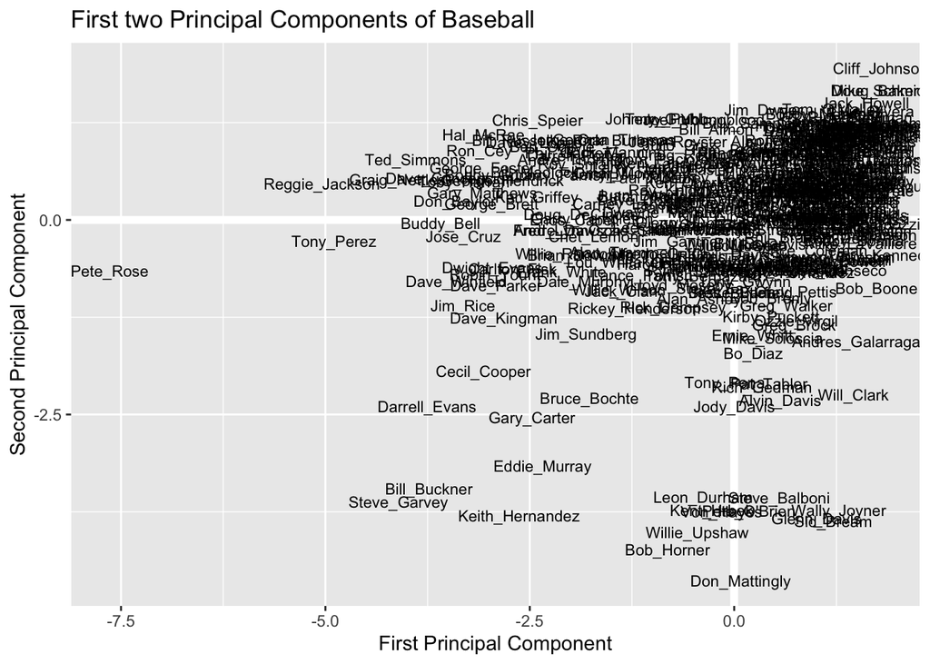

```r
ggplot(PC, aes(PC1, PC2)) +
  modelr :: geom_ref_line(h = 0) +
  modelr :: geom_ref_line(v = 0) +
   geom_text(aes(label = Names), size = 3) +
  xlab("First Principal Component") +
  ylab("Second Principal Component") +
  ggtitle("First two Principal Components of Baseball")
```

** The covariance between the two principal components is zero. Alan_Ashby, Alan_Trammell represent contrast with Al_Newman from PC1 and PC2 **

### Task 7: Perform task 1 to 6 using correlation matrix. Compare the results with the ones obtained from covariance matrix. Do the interpretation of the components differ?

```r
#TASK 1

cor_mat <- cor(indata_)

head(cor_mat)
```

```
##           atbat86    hits86   homer86    runs86     rbi86   walks86       years
## atbat86 1.0000000 0.9679388 0.5921985 0.9130603 0.8205392 0.6698451 0.047371739
## hits86  0.9679388 1.0000000 0.5621579 0.9221872 0.8110732 0.6412106 0.044766557
## homer86 0.5921985 0.5621579 1.0000000 0.6509882 0.8551222 0.4810143 0.116318335
## runs86  0.9130603 0.9221872 0.6509882 1.0000000 0.7982057 0.7322128 0.004541271
## rbi86   0.8205392 0.8110732 0.8551222 0.7982057 1.0000000 0.6159971 0.146168128
## walks86 0.6698451 0.6412106 0.4810143 0.7322128 0.6159971 1.0000000 0.136474971
##             atbat      hits  homeruns      runs       rbi     walks    outs86
## atbat86 0.2355264 0.2527170 0.2366590 0.2665340 0.2440531 0.1661231 0.3175498
## hits86  0.2275649 0.2558149 0.2027120 0.2617869 0.2320050 0.1518182 0.3106735
## homer86 0.2218821 0.2206266 0.4932269 0.2623606 0.3519790 0.2331537 0.2829229
## runs86  0.1864974 0.2048297 0.2279132 0.2505561 0.2059759 0.1821682 0.2793472
## rbi86   0.2946884 0.3082011 0.4417712 0.3232846 0.3931837 0.2509136 0.3431864
## walks86 0.2771748 0.2806711 0.3324732 0.3384780 0.3086314 0.4245071 0.2995147
##           assist86    error86
## atbat86  0.3538240 0.35211719
## hits86   0.3204549 0.31003782
## homer86 -0.1063286 0.03931765
## runs86   0.2205674 0.24047503
## rbi86    0.1065910 0.19336973
## walks86  0.1496561 0.12938206
```

```r
# The diagonal values of the correlation matrix is equal to one.

#TASK 2
ortho <- cor_mat * t(cor_mat)
ortho
```

```
##              atbat86      hits86     homer86       runs86      rbi86    walks86
## atbat86  1.000000000 0.936905564 0.350699025 8.336792e-01 0.67328463 0.44869240
## hits86   0.936905564 1.000000000 0.316021488 8.504292e-01 0.65783979 0.41115103
## homer86  0.350699025 0.316021488 1.000000000 4.237856e-01 0.73123398 0.23137479
## runs86   0.833679164 0.850429216 0.423785618 1.000000e+00 0.63713229 0.53613565
## rbi86    0.673284626 0.657839788 0.731233985 6.371323e-01 1.00000000 0.37945246
## walks86  0.448692401 0.411151032 0.231374794 5.361357e-01 0.37945246 1.00000000
## years    0.002244082 0.002004045 0.013529955 2.062315e-05 0.02136512 0.01862542
## atbat    0.055472664 0.051785772 0.049231667 3.478128e-02 0.08684124 0.07682586
## hits     0.063865904 0.065441246 0.048676115 4.195521e-02 0.09498790 0.07877624
## homeruns 0.056007478 0.041092139 0.243272796 5.194443e-02 0.19516181 0.11053845
## runs     0.071040365 0.068532361 0.068833092 6.277836e-02 0.10451296 0.11456734
## rbi      0.059561930 0.053826331 0.123889226 4.242608e-02 0.15459344 0.09525334
## walks    0.027596900 0.023048762 0.054360633 3.318525e-02 0.06295763 0.18020627
## outs86   0.100837884 0.096518013 0.080045385 7.803487e-02 0.11777691 0.08970905
## assist86 0.125191414 0.102691343 0.011305772 4.864996e-02 0.01136165 0.02239695
## error86  0.123986513 0.096123449 0.001545878 5.782824e-02 0.03739185 0.01673972
##                 years        atbat         hits   homeruns         runs
## atbat86  2.244082e-03 5.547266e-02 6.386590e-02 0.05600748 0.0710403651
## hits86   2.004045e-03 5.178577e-02 6.544125e-02 0.04109214 0.0685323610
## homer86  1.352995e-02 4.923167e-02 4.867611e-02 0.24327280 0.0688330919
## runs86   2.062315e-05 3.478128e-02 4.195521e-02 0.05194443 0.0627783564
## rbi86    2.136512e-02 8.684124e-02 9.498790e-02 0.19516181 0.1045129616
## walks86  1.862542e-02 7.682586e-02 7.877624e-02 0.11053845 0.1145673438
## years    1.000000e+00 8.469325e-01 8.165491e-01 0.52834311 0.7794716428
## atbat    8.469325e-01 1.000000e+00 9.901513e-01 0.63813962 0.9669681521
## hits     8.165491e-01 9.901513e-01 1.000000e+00 0.61356898 0.9694545203
## homeruns 5.283431e-01 6.381396e-01 6.135690e-01 1.00000000 0.6727981706
## runs     7.794716e-01 9.669682e-01 9.694545e-01 0.67279817 1.0000000000
## rbi      7.548345e-01 9.010163e-01 8.932915e-01 0.86394000 0.8906999592
## walks    7.031377e-01 8.217434e-01 7.937991e-01 0.63997258 0.8608256897
## outs86   2.194042e-05 3.879153e-03 5.859403e-03 0.01270680 0.0041190198
## assist86 6.502557e-03 4.152787e-06 6.365105e-06 0.02512570 0.0005279954
## error86  2.628951e-02 4.478533e-03 3.938325e-03 0.01907569 0.0071225362
##                 rbi       walks       outs86     assist86     error86
## atbat86  0.05956193 0.027596900 1.008379e-01 1.251914e-01 0.123986513
## hits86   0.05382633 0.023048762 9.651801e-02 1.026913e-01 0.096123449
## homer86  0.12388923 0.054360633 8.004538e-02 1.130577e-02 0.001545878
## runs86   0.04242608 0.033185253 7.803487e-02 4.864996e-02 0.057828238
## rbi86    0.15459344 0.062957635 1.177769e-01 1.136165e-02 0.037391853
## walks86  0.09525334 0.180206268 8.970905e-02 2.239695e-02 0.016739717
## years    0.75483453 0.703137667 2.194042e-05 6.502557e-03 0.026289506
## atbat    0.90101629 0.821743426 3.879153e-03 4.152787e-06 0.004478533
## hits     0.89329154 0.793799101 5.859403e-03 6.365105e-06 0.003938325
## homeruns 0.86394000 0.639972576 1.270680e-02 2.512570e-02 0.019075694
## runs     0.89069996 0.860825690 4.119020e-03 5.279954e-04 0.007122536
## rbi      1.00000000 0.782739778 1.212163e-02 6.302350e-03 0.010198971
## walks    0.78273978 1.000000000 3.438402e-03 1.531138e-03 0.014036261
## outs86   0.01212163 0.003438402 1.000000e+00 6.262007e-04 0.012093740
## assist86 0.00630235 0.001531138 6.262007e-04 1.000000e+00 0.498947306
## error86  0.01019897 0.014036261 1.209374e-02 4.989473e-01 1.000000000
```

```r
if (nrow(cor_mat) == ncol(cor_mat)) {
  cat("The matrix is square. \n")
} else {
  cat("The matrix is not square. \n")
}
```

```
## The matrix is square.
```

```r
is_symmetric <- all(cor_mat == t(cor_mat))
if(is_symmetric) {
  cat("The matrix is symmetric. \n")
} else {
  cat("The matrix is not symmetric. \n")
}
```

```
## The matrix is symmetric.
```

```r
# The correlation matrix is square symmetric.

#TASK 3
eigen_Res1 <- eigen(cor_mat, only.values = FALSE)
v1 <- eigen_Res1$values
e1 <- eigen_Res1$vectors
print(v1)
```

```
##  [1] 7.366056837 4.166375857 1.654217679 0.859043394 0.673254545 0.474174547
##  [7] 0.251326562 0.182284973 0.125316864 0.094027120 0.059962431 0.049501449
## [13] 0.024908704 0.013744556 0.004589979 0.001214502
```

```r
print(e1)
```

```
##              [,1]       [,2]        [,3]         [,4]         [,5]         [,6]
##  [1,] -0.21475291  0.3710829  0.04931016  0.089230484 -0.107320141  0.268283694
##  [2,] -0.20964311  0.3666567  0.03090917  0.104599716 -0.155595637  0.377079284
##  [3,] -0.20807103  0.2318888 -0.34017577  0.086075355  0.527613436 -0.200659126
##  [4,] -0.20712836  0.3676683 -0.06651153  0.168822458 -0.192583129  0.099014607
##  [5,] -0.24352563  0.3051849 -0.17320371  0.062455892  0.293055453  0.042159393
##  [6,] -0.21721411  0.2423107 -0.06643130  0.022710120 -0.516493629 -0.652318478
##  [7,] -0.27898040 -0.2687635  0.09281411 -0.020721007 -0.007563666  0.160002213
##  [8,] -0.32665328 -0.1995767  0.12165821 -0.017569231 -0.033006412  0.149942142
##  [9,] -0.32707840 -0.1897778  0.11842192 -0.023748219 -0.048704937  0.197567582
## [10,] -0.31147118 -0.1402878 -0.11451611  0.001455984  0.297516306 -0.248553486
## [11,] -0.33386263 -0.1807982  0.08684090  0.013705313 -0.075592691  0.077960167
## [12,] -0.33445393 -0.1799875  0.01230313 -0.035188484  0.134575188 -0.003459173
## [13,] -0.31205227 -0.1964464  0.06219649 -0.010339933 -0.174682877 -0.300170704
## [14,] -0.08720083  0.1621705 -0.16692056 -0.950531787 -0.081919377  0.089180392
```

[output cut: 36 more lines]

```r
#There are no exponential eigenvalues and eigen vectors are approximately equal to zero.

#TASK 4
sqrt1 <- (e1 * (v1) ^ (-1/2) * t(e1))
print(sqrt1)
```

```
##               [,1]         [,2]         [,3]         [,4]         [,5]
##  [1,]  0.016992629 -0.028663817 -0.003780337 -0.006809815  0.009629603
##  [2,] -0.038112929  0.065862762  0.003511460  0.018841153 -0.023263828
##  [3,] -0.007977222  0.005572764  0.089972631 -0.004451224 -0.071052065
##  [4,] -0.019940924  0.041493411 -0.006176866  0.030750550 -0.012977293
##  [5,]  0.031851967 -0.057872303 -0.111373889 -0.014658921  0.104667046
##  [6,] -0.084627827  0.132689378  0.019358091  0.003265499 -0.031622063
##  [7,]  0.007944624  0.024888197  0.023954466  0.005355178 -0.001564975
##  [8,]  0.134458808  0.068729405  0.108039514  0.001788656 -0.014869504
##  [9,]  0.113640167  0.040387064  0.107861100 -0.029679144  0.056361552
## [10,]  0.070501733 -0.002760605  0.043161775 -0.001757686  0.446583276
## [11,]  0.226967159  0.157009126  0.051976306  0.009692675  0.056597726
## [12,] -0.894285683 -0.026711215  0.018823992  0.084382038 -0.263568023
## [13,]  0.993767375 -0.902123465  0.078940087  0.013932027  0.271376837
## [14,]  0.097267523  0.224167108  0.060723378  1.285328909 -0.071139595
```

[output cut: 53 more lines]

```r
# Square root for the correlation matrix using spectral decomposition.

#TASK 5
PVE1 <- eigen_Res1$values / sum(eigen_Res1$values)
PVE1
```

```
##  [1] 0.4603785523 0.2603984910 0.1033886049 0.0536902121 0.0420784091
##  [6] 0.0296359092 0.0157079101 0.0113928108 0.0078323040 0.0058766950
## [11] 0.0037476519 0.0030938406 0.0015567940 0.0008590348 0.0002868737
## [16] 0.0000759064
```

```r
cumsum(PVE1)
```

```
##  [1] 0.4603786 0.7207770 0.8241656 0.8778559 0.9199343 0.9495702 0.9652781
##  [8] 0.9766709 0.9845032 0.9903799 0.9941276 0.9972214 0.9987782 0.9996372
## [15] 0.9999241 1.0000000
```

```r
#TASK 6
evecs1 = eigen_Res1$vectors[,1:5]
colnames(evecs1) = c("e11", "e12", "e13", "e14", "e15")
row.names(evecs1) = colnames(indata_)
evecs1
```

```
##                  e11        e12         e13          e14          e15
## atbat86  -0.21475291  0.3710829  0.04931016  0.089230484 -0.107320141
## hits86   -0.20964311  0.3666567  0.03090917  0.104599716 -0.155595637
## homer86  -0.20807103  0.2318888 -0.34017577  0.086075355  0.527613436
## runs86   -0.20712836  0.3676683 -0.06651153  0.168822458 -0.192583129
## rbi86    -0.24352563  0.3051849 -0.17320371  0.062455892  0.293055453
## walks86  -0.21721411  0.2423107 -0.06643130  0.022710120 -0.516493629
## years    -0.27898040 -0.2687635  0.09281411 -0.020721007 -0.007563666
## atbat    -0.32665328 -0.1995767  0.12165821 -0.017569231 -0.033006412
## hits     -0.32707840 -0.1897778  0.11842192 -0.023748219 -0.048704937
## homeruns -0.31147118 -0.1402878 -0.11451611  0.001455984  0.297516306
## runs     -0.33386263 -0.1807982  0.08684090  0.013705313 -0.075592691
## rbi      -0.33445393 -0.1799875  0.01230313 -0.035188484  0.134575188
## walks    -0.31205227 -0.1964464  0.06219649 -0.010339933 -0.174682877
## outs86   -0.08720083  0.1621705 -0.16692056 -0.950531787 -0.081919377
## assist86 -0.01757756  0.1903801  0.65690740 -0.002281919  0.041077569
## error86  -0.01040566  0.2303827  0.56617433 -0.185519118  0.376017643
```

```r
scaled_indata_ <- scale(indata_)
PC11 <- as.matrix(scaled_indata_) %*% evecs1[,1]
PC12 <- as.matrix(scaled_indata_) %*% evecs1[,2]
PC0 <- data.frame( PC11, PC12)
head(PC0)
```

```
##                       PC11      PC12
## Al_Newman        3.7969832 -1.093449
## Alan_Ashby      -0.2451065 -1.300926
## Alan_Trammell   -3.2996121  2.517660
## Alan_Wiggins     2.2314362 -1.483109
## Alex_Trevino     1.8784710 -1.248344
## Alfredo_Griffin -1.2276243  1.822257
```

** The first component in PC11 represent a contrast between (Alan_Trammell, Al_Newman), (Alex_Trevino, Alfredo_Griffin) and in PC12 (Al_Newman, Alan_Ashby, Alan_Wiggins) shows negative linear relationship. **